# Práctica 3.1: Regresión lineal

## Instrucións

Isto é un **Jupyter Notebook**, un documento que integra código Python nun arquivo Markdown. Isto permítenos, ir exexutando celdas de código pouco a pouco, así como xerar automáticamente un informe ben formateado da práctica.

Podes engadir unha celda co botón **"Insert"** da barra de ferramentas, e cambiar seu tipo con **"Cell > Cell Type"**

Para executar unha celda de código, seleccionarémola e pulsaremos a botón **"▶ Run"** da barra de ferramentas. Para pasar o documento a HTML, seleccionaremos **"File > Download as > HTML (.html)"**

Segue este guión ata o final. Executa o código proporcionado paso a paso comprendendo o que estás a facer e reflexionando sobre os resultados. Haberá preguntas intercaladas ao longo do guión, responde a todas elas na sección reservada para ese fin: **"Respostas ao cuestionario"**. Por favor, non modifiques ningunha liña de código agás cando se che pida explícitamente.

Non esquezas insertar o teu **nome e apelidos** na celda superior.

## Entrega da práctica

A data límite de entrega será a indicada no Campus Virtual. A entrega consistirá nun único arquivo comprimido co nome `APELIDOS_NOME_RegresionLineal.zip` que conteña os seguintes ficheiros:

- `APELIDOS_NOME_RegresionLineal.html`: Arquivo HTML froito da exportación do presente Notebook, coas preguntas respondidas ao final do documento.
- `APELIDOS_NOME_RegresionLineal.ipynb`: Arquivo Jupyter Notebook fonte.
- Arquivo de datos do problema de libre elección.

## Números aleatorios

**MOI IMPORTANTE:** Vamos a establecer un *seed* cun valor predefinido inmediatamente antes de executar calquera operación cun compoñente aleatorio. Así nos aseguraremos de que os nosos resultados sexan repetibles.

Isto é, imos poñer `np.random.seed(SEED_VALUE)` antes de:

- `train_test_split()`
- `fit()`
- `predict()`

Tamén imos poñer `random_state=SEED_VALUE` en aquelas funcións que o admitan (coma `train_test_split`).

Haberá ocasión nas que isto sexa excesivo, pero así curámonos en despistes.

# Estimación do prezo das vivendas

Neste exercicio imos asentar os conceptos vistos nas clases teóricas relativos á técnica de regresión lineal a través dun problema sinxelo. Supoñamos que somos unha inmobiliaria e queremos desenvolver unha ferramenta que nos axude a estimar un prezo recomendado de venda dos nosos inmobles. Dispomos dun pequeno dataset, `vivendas.csv`, que recolle datos de 73 vivendas vendidas pola empresa nos dous últimos anos. Neste conxunto de datos temos rexistrada a superficie total do inmoble en metros cadrados, xunto co prezo de venda en miles de euros. O noso obxectivo final é sermos capaces de, para cada novo inmoble á venda, obter un prezo recomendado de venda en base aos metros cadrados dos que dispón.

## Carga de datos e comprensión dos mesmos

Comezaremos por cargar en Python o noso conxunto de datos. O primeiro que debemos facer é asegurarnos de ter o arquivo de datos no mesmo directorio que este guión de prácticas.

Para a carga dos datos empregamos a función `read_csv()` indicando o nome do arquivo CSV. Tamén detallamos que a primeira liña do arquivo contén os nomes das columnas (`header = 0`) e que os datos están separados por comas (`delimiter = ','`). Executa o seguinte script premendo no botón **"▶ Run"** da barra de ferramentas:

```python
import pandas as pd  # Importamos a librería (isto sólo é necesario facelo unha vez)

vivendas = pd.read_csv('vivendas.csv',  # Cargamos o csv
                       delimiter=',',
                       header=0)
```

```python
vivendas.info()
```

```
<class 'pandas.core.frame.DataFrame'>
RangeIndex: 73 entries, 0 to 72
Data columns (total 2 columns):
 #   Column      Non-Null Count  Dtype
---  ------      --------------  -----
 0   superficie  73 non-null     int64
 1   prezo       73 non-null     float64
dtypes: float64(1), int64(1)
memory usage: 1.3 KB
```

Vemos unha descrición por columnas, indicándonos o tipo de dato de cada columna e cantos valores hai para cada unha delas. Hai outras alternativas á función anterior. Por exemplo, `.head()` tamén nos mostra as primeiras *n* instancias do noso conxunto de datos:

```python
vivendas.head(n=5)
```

|  | superficie | prezo |
| --- | --- | --- |
| 0 | 81 | 191.73 |
| 1 | 117 | 286.90 |
| 2 | 99 | 248.93 |
| 3 | 85 | 143.29 |
| 4 | 116 | 249.61 |

O dataset xa se atopa dispoñible no entorno Python. Agora poderémolo referenciar por medio do obxecto `vivendas`, do tipo `DataFrame`. Os dataframes son unha clase de obxectos especial en Python, usados como a estrutura de datos fundamental pola maioría do software de construción de modelos deste entorno. Un dataframe almacea unha táboa de datos na que cada fila corresponde a unha instancia (no noso caso vivendas) e cada columna a unha variable (superficie e prezo).

Unha boa práctica antes de comezar a construir un modelo de regresión é analizar e comprender os datos cos que imos a traballar. O primeiro que faremos, porén, será obter unha breve descripción dos mesmos:

- Número de instancias.
- Número de variables.
- Tipo de cada variable.
- Distribución de valores por cada variable.
- Correlación entre variables.

A función `.info()` do obxecto `DataFrame` danos unha primeira descrición dos datos bastante completa:

Con `.shape` coñecemos directamente o número de filas e columnas do dataset:

```python
vivendas.shape
```

```
(73, 2)
```

```python
print('Filas: {}'.format(vivendas.shape[0]))
print('Columnas: {}'.format(vivendas.shape[1]))
```

```
Filas: 73
Columnas: 2
```

Un consello útil para o futuro: cando teñas dúbidas sobre que fai ou que argumentos toma unha función, non dubides en consultar a axuda de Python con `help()`. Por exemplo:

```python
help(vivendas.head)
```

```
Help on method head in module pandas.core.generic:

head(n: 'int' = 5) -> 'FrameOrSeries' method of pandas.core.frame.DataFrame instance
    Return the first `n` rows.

    This function returns the first `n` rows for the object based
    on position. It is useful for quickly testing if your object
    has the right type of data in it.

    For negative values of `n`, this function returns all rows except
    the last `n` rows, equivalent to ``df[:-n]``.

    Parameters
    ----------
    n : int, default 5
        Number of rows to select.

    Returns
    -------
    same type as caller
        The first `n` rows of the caller object.

    See Also
    --------
    DataFrame.tail: Returns the last `n` rows.

    Examples
    --------
    >>> df = pd.DataFrame({'animal': ['alligator', 'bee', 'falcon', 'lion',
    ...                    'monkey', 'parrot', 'shark', 'whale', 'zebra']})
    >>> df
          animal
    0  alligator
    1        bee
    2     falcon
    3       lion
    4     monkey
    5     parrot
    6      shark
    7      whale
```

[output cut: 15 more lines]

```
          animal
    0  alligator
    1        bee
    2     falcon

    For negative values of `n`

    >>> df.head(-3)
          animal
    0  alligator
    1        bee
    2     falcon
    3       lion
    4     monkey
    5     parrot
```

> ❓ *Pregunta 1.* Indica o número de instancias e variables do dataset e o seu tipo. Investiga como acceder a valores de filas e columnas concretas dun obxecto dataframe e averigua cal foi o prezo de venda da vivenda na posición 50 do dataset. Indica o comando que empregaches para averigualo.

Tamén podemos analizar a distribución dos datos coa función `.describe()`:

```python
vivendas.describe()
```

|  | superficie | prezo |
| --- | --- | --- |
| count | 73.000000 | 73.000000 |
| mean | 127.534247 | 162.652192 |
| std | 52.721512 | 108.200288 |
| min | 75.000000 | 51.250000 |
| 25% | 91.000000 | 89.520000 |
| 50% | 109.000000 | 119.730000 |
| 75% | 138.000000 | 191.730000 |
| max | 281.000000 | 507.090000 |

> ❓ *Pregunta 2.* Cal é o prezo medio de venda dos inmobles? Que indican e significan *25%.*, *50%.* e *75%.* na saída da función anterior? Baseándote nos valores anteriores, cal é a mediana de superficie e a de precio?

Coa función `.plot()` podemos debuxar rapidamente un *scatter plot*, ou gráfico de dispersión, dos nosos datos:

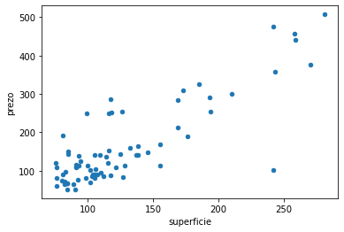

```python
vivendas.plot(kind='scatter', x='superficie', y='prezo')
```

> ❓ *Pregunta 3.* Observa detidamente o gráfico anterior. Xa que se trata dun gráfico de dispersión, que poderías comentar sobre a dispersión dos datos? Dirías que existe algún tipo de relación entre as dúas variables? Xustifica a túa resposta.

Os gráficos de dispersión axúdannos a visualizar relacións lineais entre a variable a predicir e as variables preditoras. Neste caso queremos predicir o prezo do inmoble e a única variable preditora da que dispomos é a súa superficie pero, se dispuxésemos de varias variables preditoras, deberiamos debuxar un gráfico de dispersión para cada unha delas ou un gráfico en 3 dimensións no caso de que sexan 2 variables preditoras.

Para representacións deste tipo, é conveniente empregar a librería `matplotlib`.

```python
# Indicámoslle ao Notebook que queremos figuras interactivas (isto sólo é necesario facelo unha vez)
# Isto é interesante para representacións en 3D
%matplotlib notebook

import matplotlib.pyplot as plt  # Importamos a libraría (isto sólo é necesario facelo unha vez)
import numpy as np  # Importamos NumPy, para operacións matemáticas
```

```
x  = [0.         0.04081633 0.08163265 0.12244898 0.16326531]...
y1 = [1.         0.96729486 0.8713187  0.71834935 0.51839257]...
y2 = [-1.         -0.99179001 -0.96729486 -0.92691676 -0.8713187 ]...
```

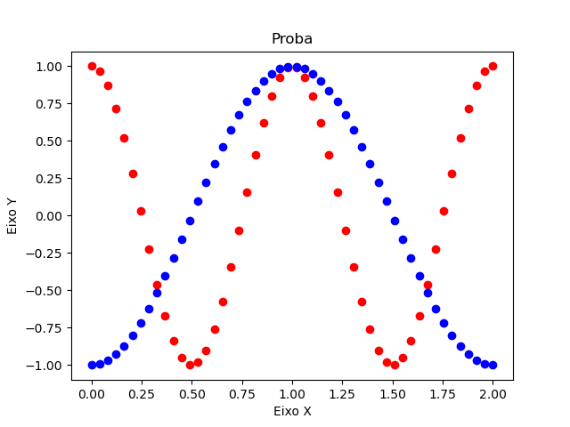

```python
# Simulamos uns datos
x = np.linspace(0.0, 2.0)
y1 = np.cos(2 * np.pi * x)
y2 = np.cos(np.pi + np.pi * x)

print('x  = {}...'.format(x[:5]))
print('y1 = {}...'.format(y1[:5]))
print('y2 = {}...'.format(y2[:5]))


# Debuxamos os datos
fig = plt.figure()  # Creamos unha figura (contenedor para elementos a debuxar)
ax = fig.add_subplot(111, projection='rectilinear')  # Engadimos un Axes á figura (contén os elementos do debuxo)

ax.scatter(x, y1, color="red")  # Engadimos un scatterplot vermello
ax.scatter(x, y2, color="blue")  # Engadimos un scatterplot azul

ax.set_title("Proba")  # Poñemos un título

plt.xlabel("Eixo X")  # Nombramos os eixos
plt.ylabel("Eixo Y")

plt.show()  # Mostramos a figura por pantalla
```

Analizando o gráfico de dispersión das vivendas xa nos puidemos facer unha idea da dependencia entre as dúas variables. Outro xeito de analizar esta dependencia é estudando a súa correlación. A correlación é unha medida estatística que amosa o grao de dependencia lineal entre dúas variables. Esta medida pode tomar valores no rango [-1, +1]:

- Se o valor dunha das variables medra de xeito constante conforme aumenta o valor da outra, entón dicimos que teñen unha forte correlación positiva (valores próximos a +1).
- Se o valor dunha das variables diminúe de xeito constante cando o valor da outra aumenta, entón teñen unha forte correlación negativa (valores próximos a -1).
- Se as dúas variables están pouco relacionadas entón obtemos valores próximos a 0.

En Python podemos obter o coeficiente de correlación empregando a función `.corr()` dunha columna do dataframe sobre a outra columna:

```python
vivendas['superficie'].corr(vivendas['prezo'])
```

```
0.8337718450638245
```

Observa como accedemos a cada unha das columnas do dataframe.

Se traballásemos con máis de 2 variables resultaría máis doado invocar a función `.corr()` directamente sobre o dataframe, para obter unha matriz de correlacións entre cada par de variables:

```python
vivendas.corr()
```

|  | superficie | prezo |
| --- | --- | --- |
| superficie | 1.000000 | 0.833772 |
| prezo | 0.833772 | 1.000000 |

## Construción dun modelo de regresión a baixo nivel

Imos construir un regresor lineal empregando o método de descenso do gradiente que xa vimos nas clases expositivas. Neste caso imos empregar as dúas variables das que dispomos directamente, pero ten en conta que habitualmente antes de adestrar un modelo realízase unha etapa de preprocesado na que, entre outras cousas, seleccionamos as instancias e as variables que queremos empregar na aprendizaxe.

Queremos obter unha función lineal $h_\theta (x)$ (unha recta) que, a partir dos valores de superficie das vivendas, $x$, nos prediga o seu prezo máis axeitado, $y$: $$ y = h_\theta (x) = \theta_0 + \theta_1 x, $$ onde $\theta_0$ e $\theta_1$ son os 2 parámetros que definen a recta.

Definimos a función $h_\theta (x)$ en Python:

```python
### Función de regresión lineal h ###
def h(x, th0, th1):
    return (th0 + x * th1)
```

Con esta función $h_\theta (x)$, se conñecésemos os valores óptimos dos dous parámetros $\theta_0$ e $\theta_1$ da recta, seriamos capaces de predecir un prezo aproximado ($y$) en base a unha superficie dada ($x$). Por exemplo, imaxina que $\theta_0 = 0.5$ e $\theta_1 = 3$ son os valores óptimos da recta. Se temos unha vivenda de 242 metros cadrados (vivenda 24 no dataset), podemos estimar o seu prezo así:

```python
h(x=242, th0=0.5, th1=3)
```

```
726.5
```

O prezo estimado para unha vivenda de 242 metros cadrados sería de 726500 euros. Sen embargo, o prezo real desta vivenda é:

```python
vivendas.iloc[23]
```

```
superficie    242.0
prezo         475.4
Name: 23, dtype: float64
```

A estimación supera o prezo real do inmoble.

O problema é por tanto que non coñecemos cales son os valores reais dos parámetros, necesitamos aprendelos. Para iso, definimos unha función de custo $J(\theta_0, \theta_1)$ que guíe ao algoritmo de aprendizaxe no axuste de $\theta_0$ e $\theta_1$. Empregamos o erro cadrático medio:

```python
### Erro cadrático medio ###
def ecm(reais, predicion):
    m = len(reais)  # tamaño do conxunto de datos
    erro = sum((predicion - reais)**2) / (2*m)
    return erro

### Función de custo J ###
def j(x, y, th0, th1):
    pred = h(x, th0, th1)  # predición realizada co noso regresor lineal h
    erro = ecm (y, pred)
    return erro
```

Por último, creamos unha función que implemente o descenso do gradiente, método que nos permitirá axustar a recta que mellor aproxima a nube de puntos:

```python
### Implementación do método do descenso do gradiente ###
def desc_grad(x, y, alpha=0.00001, iteracions=35):
    # Inicializamos os coeficientes a 0
    theta0 = 0
    theta1 = 0
    hist_custos = []

    for i in range(iteracions):
        # Calculamos o erro cometido coa función de custo
        custo = j(x, y, theta0, theta1)
        hist_custos.append(custo)

        ## Actualizamos os valores dos coeficientes theta0 e theta1
        pred = h(x, theta0, theta1)  # predición realizada co noso regresor lineal h
        m = len(x)                # tamaño do conxunto de datos
        theta0 = theta0 - alpha * sum(pred-y) / m
        theta1 = theta1 - alpha * sum((pred-y) * x) / m


        # Graficamos a iteración
        if i%2 == 0 or i == iteracions:  # Graficamos de 2 en 2 pasos
            fig = plt.figure(figsize=(20, 5))
            ax1 = fig.add_subplot(121, projection='rectilinear')
            ax2 = fig.add_subplot(122, projection='rectilinear')

            ax1.scatter(x, y, color="red")
            line_x_vals = np.array(ax1.get_xlim())
            line_y_vals = theta0 + theta1 * line_x_vals
            ax1.plot(line_x_vals, line_y_vals, '--')
            ax1.set_title("Iteración {}:     y = {} + {} * x".format(i, theta0, theta1))
            ax1.set_xlabel("prezo")
            ax1.set_ylabel("superficie")

            ax2.plot(range(i+1), hist_custos, '--', color="green")
            ax2.set_title("Custo: {}".format(custo))
            ax2.set_xlabel("iteración")
            ax2.set_ylabel("custo")

            plt.show()
```

Agora, simplemente chamamos á función anterior pasándolle como datos a superficie e prezo das vivendas:

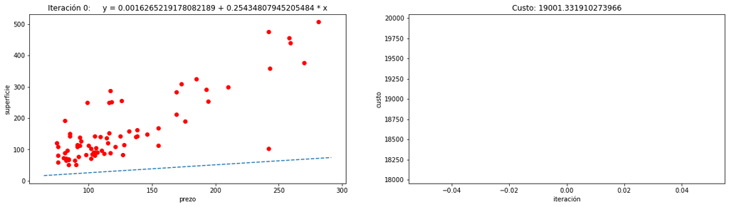

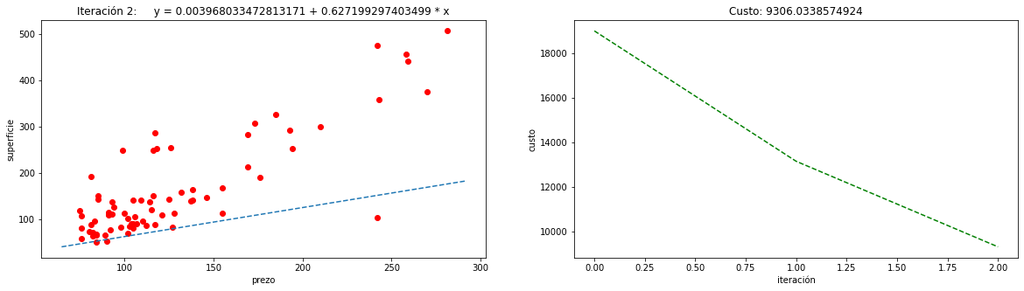

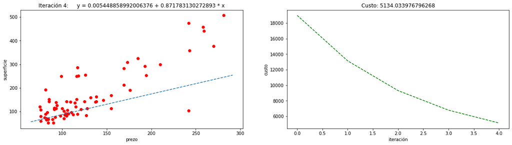

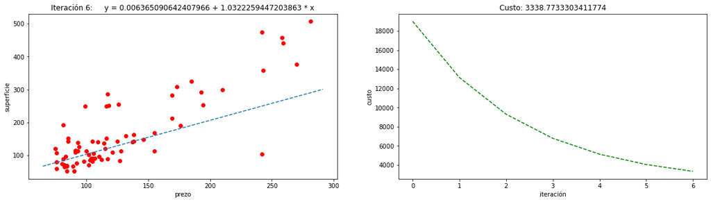

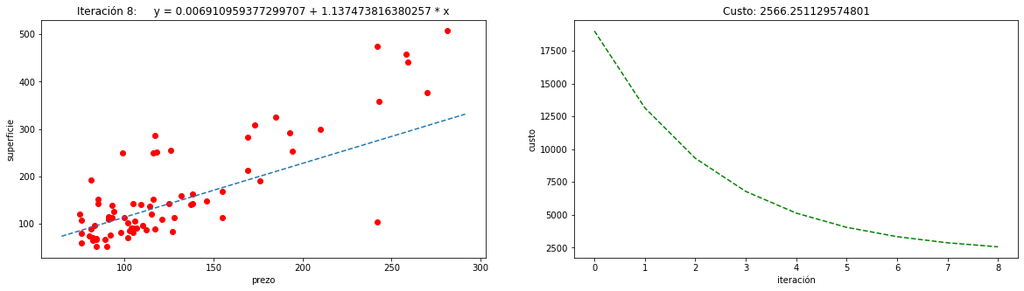

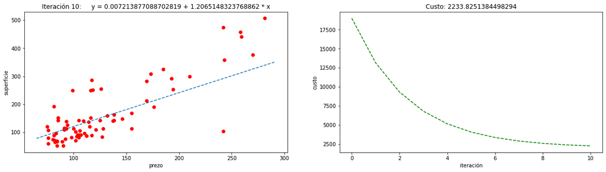

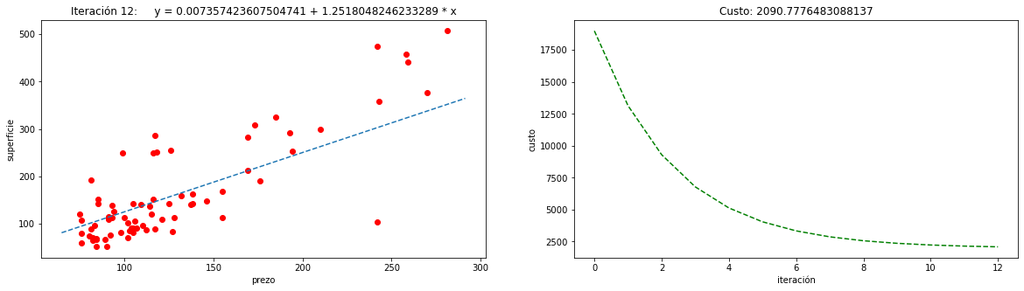

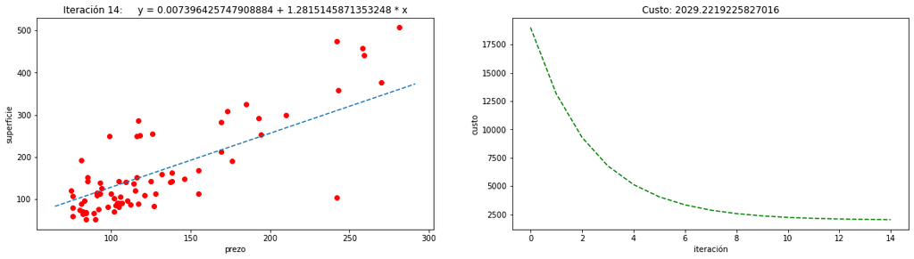

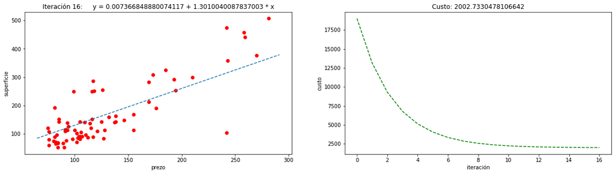

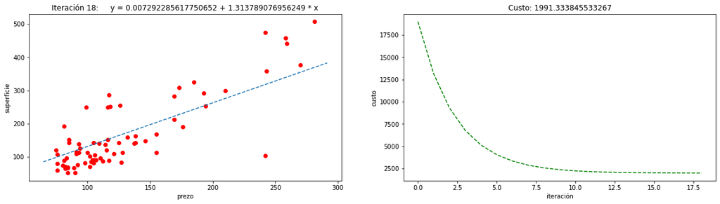

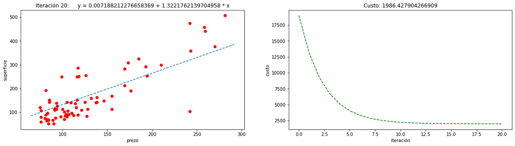

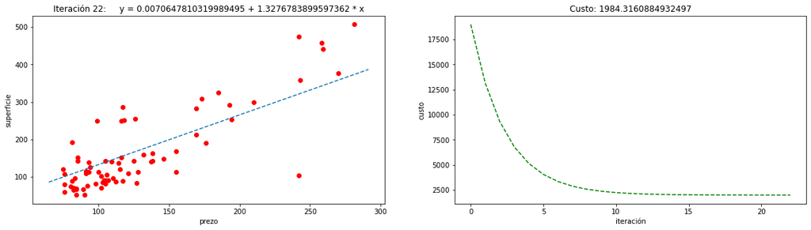

[6 more figures not shown]

```python
# Desactivamos a interactividade das figuras. Xa non nos interesa
%matplotlib inline

desc_grad(vivendas['superficie'], vivendas['prezo'], alpha = 0.00001, iteracions = 35)
```

> ❓ *Pregunta 4.* Explica brevemente e coas túas palabras como funciona o método de descenso do gradiente. Axúdate do problema das vivendas e das gráficas anteriores na túa explicación.

> ❓ *Pregunta 5.* Proba a executar o algoritmo variando o parámetro *alpha* ($\alpha$) e o número de iteracións (podes editar o script anterior ou crear outro na sección de respostas). Analiza os resultados. Cal é a función do parámetro $\alpha$? Que sucede con valores de $\alpha$ máis grandes (por exemplo, $\alpha = 0.01$)? Cantas iteracións dirías que son necesarias para obter unha regresión aceptable?

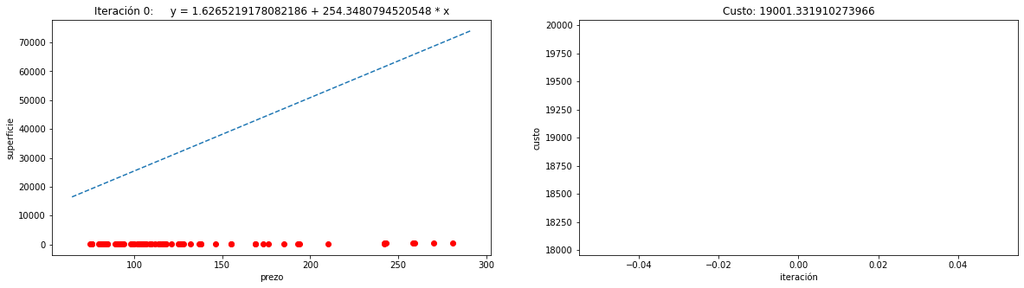

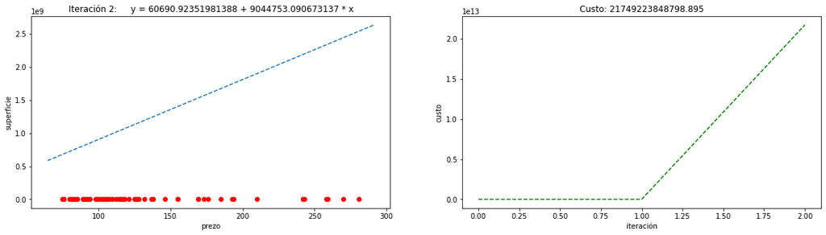

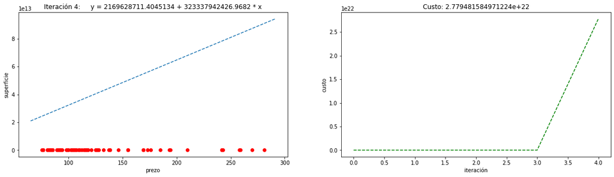

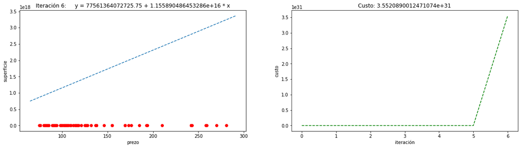

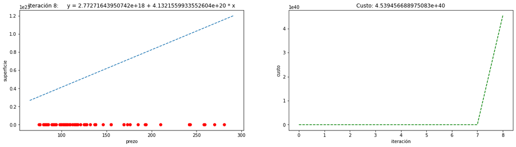

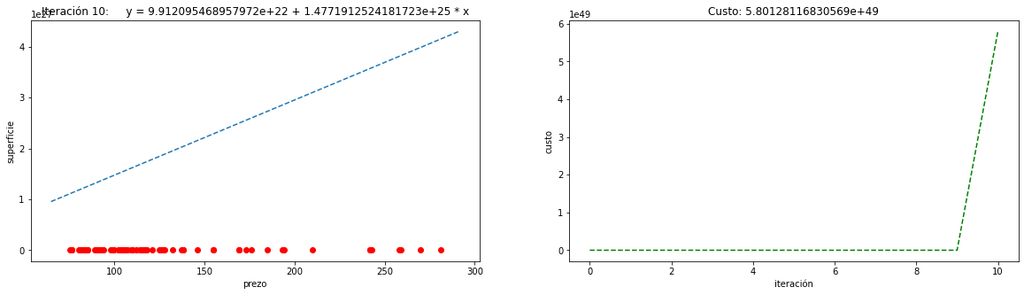

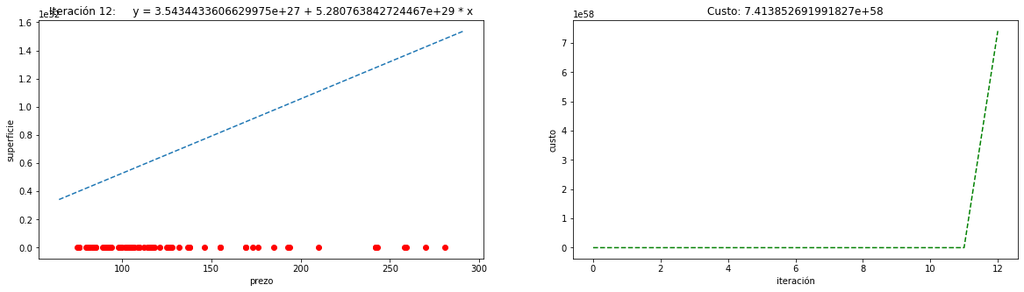

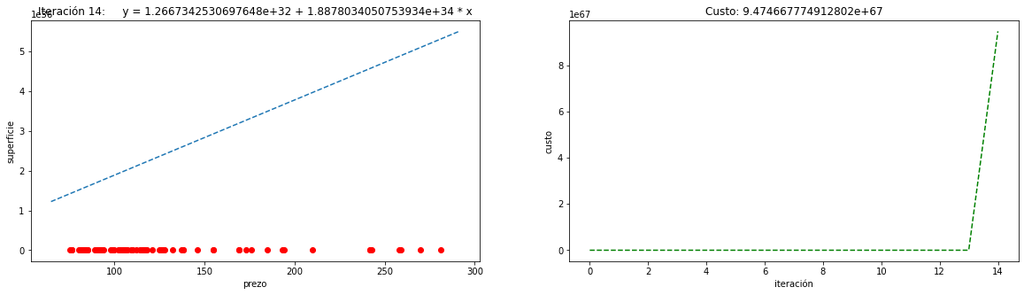

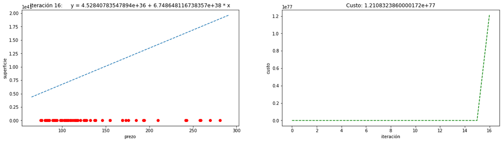

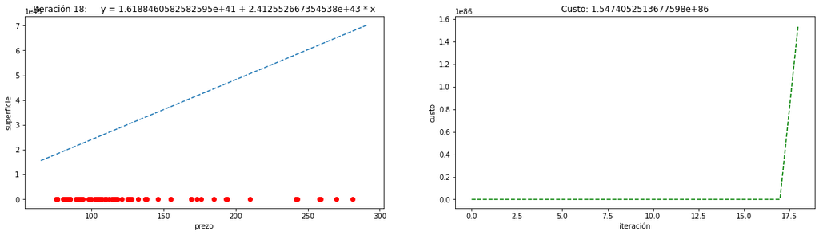

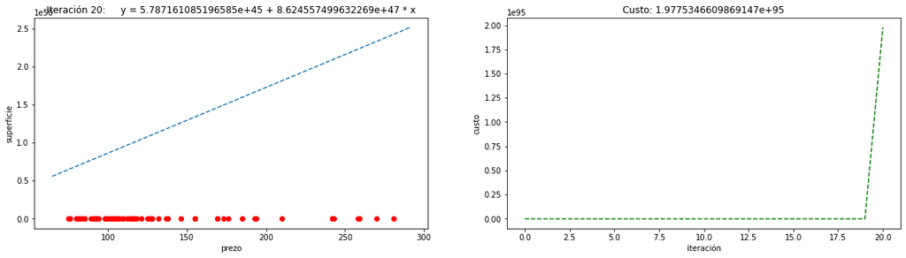

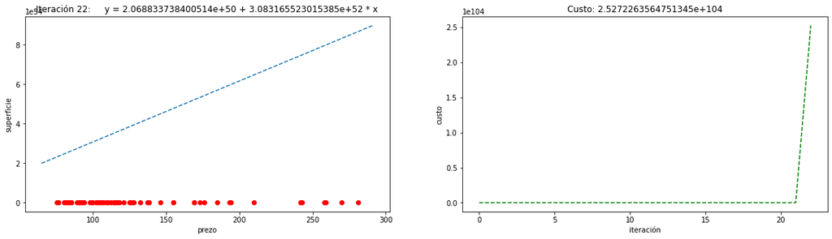

[6 more figures not shown]

```python
# Desactivamos a interactividade das figuras. Xa nonnos interesa
%matplotlib inline

desc_grad(vivendas['superficie'], vivendas['prezo'], alpha = 0.01, iteracions = 35)
```

## Construción dun modelo con `LinearRegression`

A libraría `scikit-learn` facilítanos a construción de modelos con funcións xa programadas, de xeito que non é preciso que implementemos o descenso do gradiente a man. Imos repetir o proceso anterior empregando agora a clase `sklearn.linear_model.LinearRegression`. A súa invocación é moi simple:

```python
from sklearn.linear_model import LinearRegression  # Importamos a clase (isto sólo é necesario facelo unha vez)
from sklearn.metrics import classification_report

# Dividimos o dataset en variables predictoras e dependentes
vivendas_X = vivendas.loc[:, :'superficie'].astype(float)
vivendas_Y = vivendas.loc[:, 'prezo']

model = LinearRegression()  # Definimos o modelo
model.fit(vivendas_X, vivendas_Y)  # Axustamos o modelo aos datos

# Resumo do modelo
coef = pd.DataFrame([model.intercept_, *model.coef_], ['(Intercept)', *vivendas_X.columns], columns=['Coefficients'])
coef
```

|  | Coefficients |
| --- | --- |
| (Intercept) | -55.577885 |
| superficie | 1.711149 |

> ❓ *Pregunta 6.* Explica moi brevemente a saída deste último script.

## Avaliación do modelo

Ata agora vimos como construir un modelo de regresión lineal empregando todo o dataset. Sen embargo, se o facemos deste xeito non temos forma de obter unha medida realista de como vai render o modelo con datos novos. Porén, unha boa práctica é dividir o dataset en dous conxuntos, un de adestramento (*training*) e outro de test. Habitualmente resérvase arredor do 70% dos datos para adestramento e o 30% restante para test, aínda que isto son só referencias xerais. O modelo é construído empregando o conxunto de adestramento e posteriormente é avaliado sobre o conxunto de test.

En Python podemos crear os subconxuntos de adestramento e test coa axuda da función `train_test_split()` da libraría `scikit-learn`, para así tomar unha mostra aleatoria dos datos. Para obter todos os mesmos resultados definimos unha semente coa función `random.seed()` de `NumPy`. Deste xeito, non importa cantas veces executemos o script, `train_test_split` sempre fará a mesma selección.

```python
from sklearn.model_selection import train_test_split
SEED_VALUE = 123  # NON CAMBIES ESTE SEED, así todos teremos os mesmos resultados

np.random.seed(SEED_VALUE)
vivendas_train, vivendas_test = train_test_split(vivendas, test_size=0.3, random_state=SEED_VALUE)

print('Tamaño train: {}'.format(vivendas_train.shape[0]))
print('Tamaño test: {}'.format(vivendas_test.shape[0]))
```

```
Tamaño train: 51
Tamaño test: 22
```

Construimos o modelo empregando só o conxunto de adestramento:

```python
# Dividimos o dataset en variables predictoras e dependentes
vivendas_train_X = vivendas_train.loc[:, :'superficie'].astype(float)
vivendas_train_Y = vivendas_train.loc[:, 'prezo']

model = LinearRegression()  # Definimos o modelo
np.random.seed(SEED_VALUE)
model.fit(vivendas_train_X, vivendas_train_Y)  # Axustamos o modelo aos datos

# Resumo do modelo
coef = pd.DataFrame([model.intercept_, *model.coef_], ['(Intercept)', *vivendas_train_X.columns], columns=['Coefficients'])
coef
```

|  | Coefficients |
| --- | --- |
| (Intercept) | -34.426839 |
| superficie | 1.510870 |

Agora predicimos os valores das vivendas do conxunto de validación coa axuda da función `.predict()`:

```python
# Dividimos o dataset en variables predictoras e dependentes
vivendas_test_X = vivendas_test.loc[:, :'superficie'].astype(float)
vivendas_test_Y = vivendas_test.loc[:, 'prezo']

np.random.seed(SEED_VALUE)
predicions = model.predict(vivendas_test_X)
```

A función anterior simplemente obtén os prezos das vivendas do conxunto de test a partires da función de regresión lineal que axusta o modelo. Observa que outra forma de facer esta predición é empregando a función $h_\theta(x)$ que definimos antes indicando os coeficientes $\theta_0$ e $\theta_1$ do noso modelo:

```python
predicions2 = h(vivendas_test_X, th0=coef['Coefficients']['(Intercept)'], th1=coef['Coefficients']['superficie'])
```

As predicións dos conxuntos `predicions` e `predicions2` deberían coincidir:

```python
print('Predicións obtidas coa función .predict():')
print(predicions)
print()
print('Predicións obtidas coa función h:')
print(predicions2.to_numpy()[:, 0])
```

```
Predicións obtidas coa función .predict():
[257.17108422 119.68190805 119.68190805 332.71458762 258.68195429
 165.00801008 127.23625839 331.20371755  80.39928628 140.834089
 121.19277811  92.48624682 282.85587538 124.21451825 142.34495906
 125.72538832 142.34495906 220.91020259 131.76886859 139.32321893
 356.8885087   86.44276655]

Predicións obtidas coa función h:
[257.17108422 119.68190805 119.68190805 332.71458762 258.68195429
 165.00801008 127.23625839 331.20371755  80.39928628 140.834089
 121.19277811  92.48624682 282.85587538 124.21451825 142.34495906
 125.72538832 142.34495906 220.91020259 131.76886859 139.32321893
 356.8885087   86.44276655]
```

Como dispomos das predicións dos prezos das vivendas do conxunto de test e tamén coñecemos os seus prezos reais, agora podemos avaliar o rendemento do noso modelo. Por exemplo, podemos empregar de novo o erro cadrático medio:

```python
e_cadratico = ecm(vivendas_test_Y, predicions)
print(e_cadratico)
```

```
1775.6429474014146
```

O problema do erro cadrático medio é que non resulta un indicador moi intuitivo. Sen embargo, podemos calcular a súa raíz cadrada para obter unha estimación do erro en miles de euros:

```python
np.sqrt(e_cadratico)
```

```
42.13837855686209
```

Outra posibilidade é empregar o índice de correlación entre os datos reais e as predicións:

```python
vivendas_test_Y.corr(pd.Series(predicions, vivendas_test_Y._index))
```

```
0.9160621867265676
```

> ❓ *Pregunta 7.* Por que non sería axeitado avaliar o rendemento do noso modelo empregando os mesmos datos cos que o adestramos?

## Identificación de valores atípicos (*outliers*)

Os valores atípicos, anómalos ou *outliers* son instancias do noso conxunto de datos que non seguen a tendencia habitual do dataset, sendo numéricamente distantes ao resto dos datos. Noutras palabras, son instancias que parecen inconsistentes co resto dos valores do dataset. Debemos evitar que o noso conxunto de adestramento presente estes datos atípicos xa que poden deteriorar moito a calidade dos nosos modelos.

Imos ver un exemplo sinxelo de como identificar *outliers* e analizaremos o seu impacto na calidade do modelo do prezo das vivendas. Ten en conta que esta é unha etapa habitual no preprocesado dos datos. Nós excepcionalmente ímola abordar agora aínda, tras ter un modelo, con fins ilustrativos.

Os diagramas de caixa, ou *boxplots*, son gráficos baseados en cuartiles que nos permite visualizar a distribución do conxunto de datos para cada unha das variables. En Python podemos visualizalos coa función `boxplot()` de `matplotlib`:

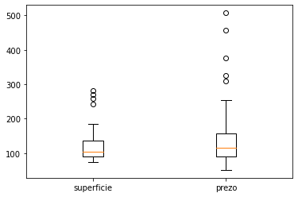

```python
box = plt.boxplot(vivendas_train, labels=vivendas_train.columns)
```

Dentro da caixa atópase o 50% dos datos. Os datos máis atípicos (círculos) están fora dos brazos da caixa. Vemos que ambas variables presentan uns poucos *outliers* na súa distribución. Estes *outliers* coñécense como univariados porque están presentes na distribución dunha soa variable. Podemos saber os valores deses *outliers* do seguinte xeito:

```python
out_superficie = box["fliers"][0].get_data()[1]
out_prezo = box["fliers"][1].get_data()[1]

print("Outliers na variable 'superficie': {}".format(out_superficie))
print("Outliers na variable 'prezo': {}".format(out_prezo))
```

```
Outliers na variable 'superficie': [258. 270. 242. 281.]
Outliers na variable 'prezo': [308.53 457.11 376.51 325.61 507.09]
```

Así coñecemos as superficies e prezos atípicas. Agora ben, que un exemplo sexa *outlier* nalgunha das dimensións non implica que sexa realmente un dato atípico no noso problema. Por exemplo, que unha vivenda teña unha superficie de 281 metros cadrados pode ser un valor atípico da dimensión Superficie se a maioría das vivendas son pequenas no dataset. Do mesmo modo, unha vivenda que custe preto de 500.000 euros pode ser atípica se o precio medio da vivenda é moito inferior.

Os *outliers* dos que realmente nos temos que preocupar son aqueles *outliers* multivariados, é dicir, que disten da tendencia nas dúas dimensións, superficie-prezo. Existen métodos de identificación de outliers en máis dunha dimensión pero, debido á súa complexidade, quedan fora desta práctica. Posto que o noso problema conta con poucas instancias, podemos facer unha inspección visual e manual:

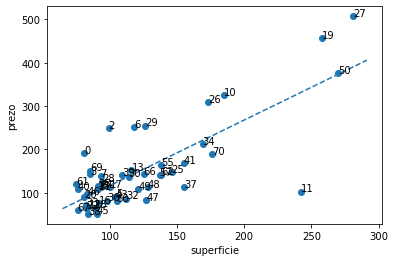

```python
# Creamos o entorno
fig = plt.figure()  # Creamos unha figura (contenedor para elementos a debuxar)
ax = fig.add_subplot(111, projection='rectilinear')  # Engadimos un Axes á figura (contén os elementos do debuxo)
plt.xlabel("superficie")  # Nombramos os eixos
plt.ylabel("prezo")

# Debuxamos o scatter
ax.scatter(vivendas_train['superficie'], vivendas_train['prezo'])

# Creamos e mostramos a recta
line_x_vals = np.array(ax.get_xlim())
line_y_vals = coef['Coefficients']['(Intercept)'] + coef['Coefficients']['superficie'] * line_x_vals
ax.plot(line_x_vals, line_y_vals, '--')

# Imprimimos os identificadores
for i in vivendas_train.index:
    ax.text(vivendas_train['superficie'][i], vivendas_train['prezo'][i], i)

plt.show()
```

Se nos fixamos no gráfico de dispersión, existe un valor moito máis distante da recta de regresión que o resto:

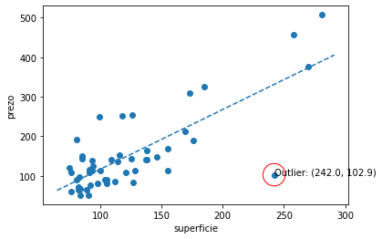

```python
# Creamos o entorno
fig = plt.figure()  # Creamos unha figura (contenedor para elementos a debuxar)
ax = fig.add_subplot(111, projection='rectilinear')  # Engadimos un Axes á figura (contén os elementos do debuxo)
plt.xlabel("superficie")  # Nombramos os eixos
plt.ylabel("prezo")

# Debuxamos o scatter
ax.scatter(vivendas_train['superficie'], vivendas_train['prezo'])

# Mostramos a recta
ax.plot(line_x_vals, line_y_vals, '--')

# Marcamos o outlier
outlier_id = 11
outlier = vivendas_train.loc[outlier_id]
ax.scatter(outlier['superficie'], outlier['prezo'], s=600, facecolors='none', edgecolors='r')
ax.text(outlier['superficie'], outlier['prezo'],
        'Outlier: ({}, {})'.format(outlier['superficie'], outlier['prezo']))
plt.show()
```

Imos ver se podemos mellorar a calidade do modelo prescindindo deste dato atípico. Eliminámolo do conxunto de adestramento e adestramos un novo modelo:

```python
# Eliminamos o outlier do conxunto
vivendas_train = vivendas_train.drop(outlier_id)

# Dividimos o dataset en variables predictoras e dependentes
vivendas_train_X = vivendas_train.loc[:, :'superficie'].astype(float)
vivendas_train_Y = vivendas_train.loc[:, 'prezo']

new_model = LinearRegression()  # Definimos un novo modelo
new_model.fit(vivendas_train_X, vivendas_train_Y)  # Axustamos o novo modelo aos datos

# Resumo do modelo
new_coef = pd.DataFrame([new_model.intercept_, *new_model.coef_], ['(Intercept)', *vivendas_train_X.columns], columns=['Coefficients'])
new_coef
```

|  | Coefficients |
| --- | --- |
| (Intercept) | -59.680167 |
| superficie | 1.759946 |

Graficamos para ver a diferenza entre o novo modelo sen o outlier e o vello:

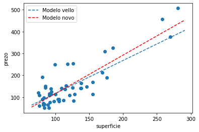

```python
# Creamos o entorno
fig = plt.figure()  # Creamos unha figura (contenedor para elementos a debuxar)
ax = fig.add_subplot(111, projection='rectilinear')  # Engadimos un Axes á figura (contén os elementos do debuxo)
plt.xlabel("superficie")  # Nombramos os eixos
plt.ylabel("prezo")

# Debuxamos o scatter
ax.scatter(vivendas_train['superficie'], vivendas_train['prezo'])

# Creamos e mostramos a recta antiga
line_x_vals = np.array(ax.get_xlim())
line_y_vals = coef['Coefficients']['(Intercept)'] + coef['Coefficients']['superficie'] * line_x_vals
ax.plot(line_x_vals, line_y_vals, '--', label='Modelo vello')

# Creamos e mostramos a recta nova
line_y_vals = new_coef['Coefficients']['(Intercept)'] + new_coef['Coefficients']['superficie'] * line_x_vals
ax.plot(line_x_vals, line_y_vals, '--', color='r', label='Modelo novo')

ax.legend()  # Facemos que se mostren as labels

plt.show()
```

Realizamos de novo a predición sobre o conxunto de test e avaliamos o rendemento:

```python
novas_predicions = new_model.predict(vivendas_test_X)
e_cadratico_novo = ecm(vivendas_test_Y, novas_predicions)

print(np.sqrt(e_cadratico_novo))
vivendas_test_Y.corr(pd.Series(novas_predicions, vivendas_test_Y._index))
```

```
37.01214130291502
```

```
0.9160621867265678
```

> ❓ *Pregunta 8.* Analiza brevemente o impacto do *outlier* no modelo de regresión.

# Respostas ao cuestionario (6 puntos)

**LEMBRA:** Non esquezas de escribir teu nome e apelidos na segunda celda do presente documento.

**Pregunta 1**

Hay 2 columnas. La primera es superficie, de tipo int64, y la segunda es prezo, de tipo float64. En el Dataset hay 73 entradas, es decir, 73 filas de datos. Para acceder a las filas, se puede utilizar fila = vivendas.loc[fila]. Para acceder a las columnas columna = vivendas.nombre_de_columna Si se quiere obtener el valor de una fila y columna en concreto, se usa vivendas.loc[fila,'nombre_de_columna']

El precio es de: 376.51

Los comandos utilizados fuero:

dato = vivendas.loc[50,'prezo'] print("El precio de la vivienda de la fila 50 es: ", dato)

**Pregunta 2** El precio medio es de 162.65. El 25%, 50%, 75% son los cuantiles, e indica cual es el valor en cada uno de ellos. Por ejemplo, el primero cuantil (25%) del precio está en 89.52, indicando que el el 25% de los datos es menor a igual a ese valor. La mediana del precio es 119.73, y la mediana de la superficie es 109.

**Pregunta 3** Vemos que los datos se encuentran muy dispersos con respecto a la mediana, alejándose mucho del valor de esta tanto para precio como para superficie. Por otro lado, vemos que lo datos se aproximan a la hipotética recta de regresión lineal generada, por lo que se puede decir que están positivamente correlados (la variable precio crece con respecto al crecimiento de la superficie). Se puede observar que hay ciertos datos atípicos (se alejan de la recta de regresión), que podrían cambiar lo bueno que es el modelo de regresión, por lo que habría que tener en cuenta su posible descarte.

**Pregunta 4** La función comienza inicializando los valores tita de la función de regresión h() a 0. Posteriormente, inicia el bucle para el método de gradiente. Primero calcula el error cometido usando la función j(). Esta utiliza los datos de 'x' para calcular la predicción con la h() tal y como está inicializada, para luego calcular el error cuadrático medio con la predicción y los datos de 'y'. El valor del error se almacena en la lista hist_custos[].

Posteriormente, se recalculan los valores de tita0 y tita1, invocando de nuevo a la función de regresión h() (para ver cual es la predicción), y ajustando los tita utilizando el error medio en la predicción, así como el valor de descenso alpha. Cabe destacar que es muy importante la elección del valor de descenso alpha, ya que si el valor es muy pequeño el algoritmo convergerá muy lento (en muchas iteracciones), haciéndolo muy costoso computacionalmente, y si es muy grande puede pasarse el míninmo del error.

Tras reajustar los valores de tita, se realiza una gráfica de como va la recta de regresión con respecto a los datos. Se realiza cada 2 iteracciones para observar de forma más clara los cambios en la función. También se grafica el error de cada iteracción, para ver cómo evoluciona con respecto al algoritmo.

Cabe destacar que el método está implementado de forma que se para en el número de iteracciones dado, y no según un factor de parada.

**Pregunta 5**

El alpha, como se a comentado previamente, es el valor de descenso, y marcará la aproximación de los valores tita de la recta de regresión.Cuanto más pequeño, más preciso va a ser, pero más iteracciones necesitará para llegar al error mínimo,ya que el descenso de este error será menor. Si se sitúan valores más grandes, puede sobrepasarse el error mínimo, y hacer que crezca cada vez más, obteniendo una recta de regresión totalmente errónea. Cuando se ejecuta desc_grad con alpha=0.01, se observa la situación comentada previamente, ya que tras la segunda iteracción, la recta de regresión ya queda por encima de los datos, y el error es creciente en vez de decreciente, haciendo que la predicción sea cada vez peor.

Se podría indicar un valor de parada para el algoritmo, cuando se considere que la variación del error entre una iteracción y otra es lo suficientemente pequeá como para dar por buena la recta de regresión. En este caso, se podría estimar en un variación del error de 0.1, que viendo la gráfica, en la iteracción 30 ya se podría considerar que la regresión es buena o aceptable. Cabe destacar que este valor depende de los datos que se quieran predecir, teniendo en cuenta la exactitud requerida y el coste computacional que conlleva.

**Pregunta 6**

El intercepto de la regresión, es el valor esperado de la variable dependiente (la variable 'y'), cuando las variables predictoras (la variable 'x') son iguales a 0, siendo el valor del theta0. Es decir, en este caso es el precio esperado cuando la superficie del piso es de 0, dando un valor de -55.58, indicando que no es una recta centrada en el centro del eje de coodenadas. El segundo valor representa la pendiente de la función de regresión, el thetha 1, que indica cuánto varía el precio por unidad de superficie. En este caso, por cada metro de supercie, el precio se va a incrementar en 1.71, en las unidades de medida dadas.

**Pregunta 7** Porque si se evalúa el rendimiento con los datos de entrenamiento, van a salir errores próximos a 0 y correlación próxima a 1, ya que la recta se ha construído teniendo en cuenta esos datos, por lo que la estimación para esos propios datos sería muy buena. Pero no sería real, ya que no se ajusta al resto de posibles datos, por lo que la evaluación del modelo de regresión no sería correcta, y nos daría una falsa visión acerca de cuanto de bueno es nuestro modelo.

**Pregunta 8** Como se puede observar, el error cuadrático medio es menor (varía de 42.13837855686209 a 37.01214130291502), y la correlación es mayor (0.9160621867265676 a 0.9160621867265678). Como se puede obsevar, la variación en el error es más notable que la variación en el coeficiente de correlación. Esto es debido a que el coeficiente de correlación se calcula con la covarianza de los datos X e Y dividida por la multiplicación de la raíz de las varianzas de X e Y, y teniendo en cuenta el tamaño de la muestra, el cambio va a ser pequeño. Cuanto más grande es la muestra, menor es el cambio con la eliminación de un valor atípico. Por otro lado, la variación de la correlación se da presiamente porque las medidas de covarianza y varianza son sensibles a datos atípicos, por lo que eliminarlos supone mejorar la predicción del modelo.

# Modelado dun problema de libre elección

## Enunciado

O problema sobre o que acabamos de traballar é un "exemplo xoguete". Na realidade, resultaría difícil poder predicir con exactitude o prezo dunha vivenda tendo en conta só unha variable (neste caso, a superficie). O máis probable é que outros factores contribúan a estimar un bo prezo para os inmobles. Algúns exemplos de outras variables continuas que se poderían empregar son a súa antigüidade, a distancia ao centro urbán máis próximo, o custo da vida na cidade, rexión ou país onde se ubica, etc.

Hai moitos portais de onde podes sacar datos. Por exemplo Kaggle, a maior comunidade de ciencia de datos e aprendizaxe automática online. Aquí tes algunhas ligazóns que podes consultar:

- ["friendly" datasets en Kaggle](https://www.kaggle.com/rtatman/fun-beginner-friendly-datasets)
- [outros datasets faciliños pensados para regresión](https://people.sc.fsu.edu/~jburkardt/datasets/regression/regression.html)

Imos traballar co dataset 80 cereals (https://www.kaggle.com/datasets/crawford/80-cereals). Carga o ficheiro cereal.csv e pon en práctica os teus coñecementos de regresión lineal. Escolle como variables preditoras aquelas que penses que poden estar linealmente correlacionada coa variable que queres predicir (*rating*). O único requerimento obrigatorio é **empregar exactamente DÚAS variables preditoras** no adestramento do modelo de regresión.

Asegúrate de comprender ben o problema e a información que estás a manexar. Fai un breve estudo dos teus datos, incluíndo gráficas e comentarios propios. De ser preciso, aplica as etapas de preprocesado que consideres, pero coidado porque quizáis che implique facer un preprocesado demasiado complexo, para o que non estás preparado aínda. Logo, obtén o modelo e avalía o seu rendemento. Non pasa nada se finalmente non hai unha boa correlación entre as variables preditoras e a variable obxectivo e o modelo realiza malas predicións. A finalidade deste exercicio é abordar un problema real e que realices un bo procedemento de análise de datos en base ao aprendido.

Obtén un modelo seguindo as boas prácticas que levamos visto. Na avaliación do exercicio terase en conta a complexidade da solución (análise, preprocesado, adestramento e test), así como a claridade nas explicacións e a boa estruturación do traballo realizado. Proporciona todo o código que consideres necesario empregando scripts como os do exercicio anterior.

## Resposta (4 puntos)

```python
# INTRODUCE O TEU CÓDIGO AQUÍ (tamén podes usar celdas Markdown para as explicacións)

import pandas as pd  # Importamos a librería

cereal = pd.read_csv('cereal.csv',  # Cargamos o csv
                       delimiter=',',
                       header=0)
#Mostramos información sobre el dataset

print('Filas: {}'.format(cereal.shape[0]))
print('Columnas: {}'.format(cereal.shape[1]))
cereal.info()
cereal.head(n=5)
```

```
Filas: 77
Columnas: 16
<class 'pandas.core.frame.DataFrame'>
RangeIndex: 77 entries, 0 to 76
Data columns (total 16 columns):
 #   Column    Non-Null Count  Dtype
---  ------    --------------  -----
 0   name      77 non-null     object
 1   mfr       77 non-null     object
 2   type      77 non-null     object
 3   calories  77 non-null     int64
 4   protein   77 non-null     int64
 5   fat       77 non-null     int64
 6   sodium    77 non-null     int64
 7   fiber     77 non-null     float64
 8   carbo     77 non-null     float64
 9   sugars    77 non-null     int64
 10  potass    77 non-null     int64
 11  vitamins  77 non-null     int64
 12  shelf     77 non-null     int64
 13  weight    77 non-null     float64
 14  cups      77 non-null     float64
 15  rating    77 non-null     float64
dtypes: float64(5), int64(8), object(3)
memory usage: 9.8+ KB
```

|  | name | mfr | type | calories | protein | fat | sodium | fiber | carbo | sugars | potass | vitamins | shelf | weight | cups | rating |
| --- | --- | --- | --- | --- | --- | --- | --- | --- | --- | --- | --- | --- | --- | --- | --- | --- |
| 0 | 100% Bran | N | C | 70 | 4 | 1 | 130 | 10.0 | 5.0 | 6 | 280 | 25 | 3 | 1.0 | 0.33 | 68.402973 |
| 1 | 100% Natural Bran | Q | C | 120 | 3 | 5 | 15 | 2.0 | 8.0 | 8 | 135 | 0 | 3 | 1.0 | 1.00 | 33.983679 |
| 2 | All-Bran | K | C | 70 | 4 | 1 | 260 | 9.0 | 7.0 | 5 | 320 | 25 | 3 | 1.0 | 0.33 | 59.425505 |
| 3 | All-Bran with Extra Fiber | K | C | 50 | 4 | 0 | 140 | 14.0 | 8.0 | 0 | 330 | 25 | 3 | 1.0 | 0.50 | 93.704912 |
| 4 | Almond Delight | R | C | 110 | 2 | 2 | 200 | 1.0 | 14.0 | 8 | -1 | 25 | 3 | 1.0 | 0.75 | 34.384843 |

```python
#Veamos como es la distribución, visualizando 'sugars' y 'vitamins'
cereal[['sugars','fiber']].describe()
```

|  | sugars | fiber |
| --- | --- | --- |
| count | 77.000000 | 77.000000 |
| mean | 6.922078 | 2.151948 |
| std | 4.444885 | 2.383364 |
| min | -1.000000 | 0.000000 |
| 25% | 3.000000 | 1.000000 |
| 50% | 7.000000 | 2.000000 |
| 75% | 11.000000 | 3.000000 |
| max | 15.000000 | 14.000000 |

```python
resultados = cereal[cereal['sugars'] == -1]
print(resultados)
```

```
              name mfr type  calories  protein  fat  sodium  fiber  carbo  \
57  Quaker Oatmeal   Q    H       100        5    2       0    2.7   -1.0

    sugars  potass  vitamins  shelf  weight  cups     rating
57      -1     110         0      1     1.0  0.67  50.828392
```

```
x1  = 0    6
1    8
2    5
3    0
4    8
Name: sugars, dtype: int64...
x2 = 0    10.0
1     2.0
2     9.0
3    14.0
4     1.0
Name: fiber, dtype: float64...
y = 0    68.402973
1    33.983679
2    59.425505
3    93.704912
4    34.384843
Name: rating, dtype: float64...
```

[figure not shown]

|  | sugars | fiber | rating |
| --- | --- | --- | --- |
| sugars | 1.000000 | -0.141205 | -0.759675 |
| fiber | -0.141205 | 1.000000 | 0.584160 |
| rating | -0.759675 | 0.584160 | 1.000000 |

```python
%matplotlib notebook

import matplotlib.pyplot as plt  # Importamos a libraría (isto sólo é necesario facelo unha vez)
import numpy as np  # Importamos NumPy, para operacións matemáticas

# Simulamos uns datos
x1 = cereal['sugars']
x2 = cereal['fiber']
y = cereal['rating']

print('x1  = {}...'.format(x1[:5]))
print('x2 = {}...'.format(x2[:5]))
print('y = {}...'.format(y[:5]))


# Debuxamos os datos
fig = plt.figure()  # Creamos unha figura (contenedor para elementos a debuxar)
ax = fig.add_subplot(111, projection='rectilinear')  # Engadimos un Axes á figura (contén os elementos do debuxo)

ax.scatter(x1, y, color="red")  # Engadimos un scatterplot vermello
ax.scatter(x2, y, color="blue")  # Engadimos un scatterplot azul

ax.set_title("Gráfico de sugars, fiber con respecto a rating")  # Poñemos un título

plt.xlabel("Azul-Sugars Rojo-Fiber")  # Nombramos os eixos
plt.ylabel("Rating")

plt.show()  # Mostramos a figura por pantalla

#cereal.plot(kind='scatter', x='sugars', y='rating')
cereal[['sugars','fiber','rating']].corr()
```

Como se puede observar en el gráfico, parece que va a haber una cierta correlación tanto entre la variable sugars con rating, así como con fiber y rating. En el caso de sugar y rating, va a ser una correlación negativa, ya que la recta de regresión calculada va a tener pendiente negativa (los datos de rating disminuyen a medida que aumenta el sugar), mientras que entre fiber y rating va a haber una correlación positiva, ya eu la pendiente de la recta será positiva. Esto se puede verificar viendo los datos que aportan la funcion corr(). Se observa que la correlación entre sugars y rating es de -0.75, lo que se consideraría alta, y entre fiber y rating es de 0.58, lo que se considera media. Posteriormente se analizará con más detalle estos datos, teniendo en cuenta el modelo de regresión. Cabe destacar que los gráficos se han realizado mostrando la dependencia entre las variables 2 a 2, con una variable como predictora, pero el modelo se evaluará una regresión múltiple, poniendo las 2 variables como predictoras.

```python
# Desactivamos a interactividade das figuras. Xa non nos interesa
%matplotlib inline

#Ahora creamos el modelo de regresión lineal múltiple con el LinearRegression de sklearn.linear_model

from sklearn.linear_model import LinearRegression  # Importamos a clase (isto sólo é necesario facelo unha vez)
from sklearn.metrics import classification_report

# Dividimos o dataset en variables predictoras e dependentes
#Destacar qeu se hace una conversión a float, ya que la variable dependiente rating es float
cereal_X = cereal.loc[:,['sugars', 'fiber']].astype(float)
cereal_Y = cereal.loc[:, 'rating']

model = LinearRegression()  # Definimos o modelo
model.fit(cereal_X, cereal_Y)  # Axustamos o modelo aos datos

# Resumo do modelo
coef = pd.DataFrame([model.intercept_, *model.coef_], ['(Intercept)', *cereal_X.columns], columns=['Coefficients'])
coef
```

|  | Coefficients |
| --- | --- |
| (Intercept) | 51.609656 |
| sugars | -2.183676 |
| fiber | 2.867923 |

Como se puede observar, tenemos que el modelo va a tener un intercepto de 51.6 (lo que significa que si ponemos 0 sugars y 0 fiber, el rating va a ser de 51.6). Por otro lado, el rating descenderá -2.18 por cada unidad de sugar que aumente, y aumentará 2.86 por cada unidad de fibra que aumente.